# Big Chico Creek

Sadie Gill, Mark Tompkins, Erin Cain

July 17, 2019

## Future Data Improvements

None Planned

## Instream Spawning and Rearing Habiat

**Data Source:** No watershed specific salmonid habitat data was available for Big Chico Creek. A regional weighted usable area (WUA) relationship with flow was derived for Big Chico Creek by averaging the WUA values on Battle Creek, Butte Creek, Clear Creek, Cottonwood Creek and Cow Creek. The geomorphic and hydrologic conditions in Big Chico Creek (watershed area = 930 sqkm, active channel width = 14.8 meters) are similar to those on Battle Creek (watershed area = 957 sqkm; active channel width = 22.5 m), Butte Creek (watershed area = 2123 sqkm; active channel width = 15.2 m), Clear Creek (watershed area = 645 sqkm; active channel width = 18 m), Cottonwood Creek (watershed area = 2444 sqkm; active channel width = 28.25 m), and Cow Creek (watershed area = 1107 sqkm; active channel width = 8.5 m). The regional WUA relationships for Big Chico Creek were multiplied by the length of spawning and rearing extents mapped by the Science Integration Team (SIT).

### Combine Spawning and Rearing Data

The instream spawning and rearing habitat data described above for Fall Run Chinook Salmon (FR) is combined for use in the DSM in the following format.

| flow_cfs | FR_spawn_wua | FR_fry_wua | FR_juv_wua | watershed |
| --- | --- | --- | --- | --- |
| 50 | 1680.581 | 13123.57 | 11114.86 | Big Chico Creek |
| 75 | 2010.154 | 12408.41 | 12034.16 | Big Chico Creek |
| 100 | 2187.526 | 11471.74 | 12448.54 | Big Chico Creek |
| 125 | 2279.997 | 10641.96 | 12463.12 | Big Chico Creek |
| 150 | 2349.041 | 10026.15 | 12230.09 | Big Chico Creek |

*…with 18 more rows*

### Spawning WUA

The instream spawning habitat weighted usable areas for Fall Run Chinook Salmon in Big Chico Creek.

#### Spawning WUA Plot

The following plot shows the weighted usable spawning area in square feet per thousand feet of river for Fall Run Chinook Salmon. These area per length rates are multiplied by the total spawning reach length mapped by the SIT.

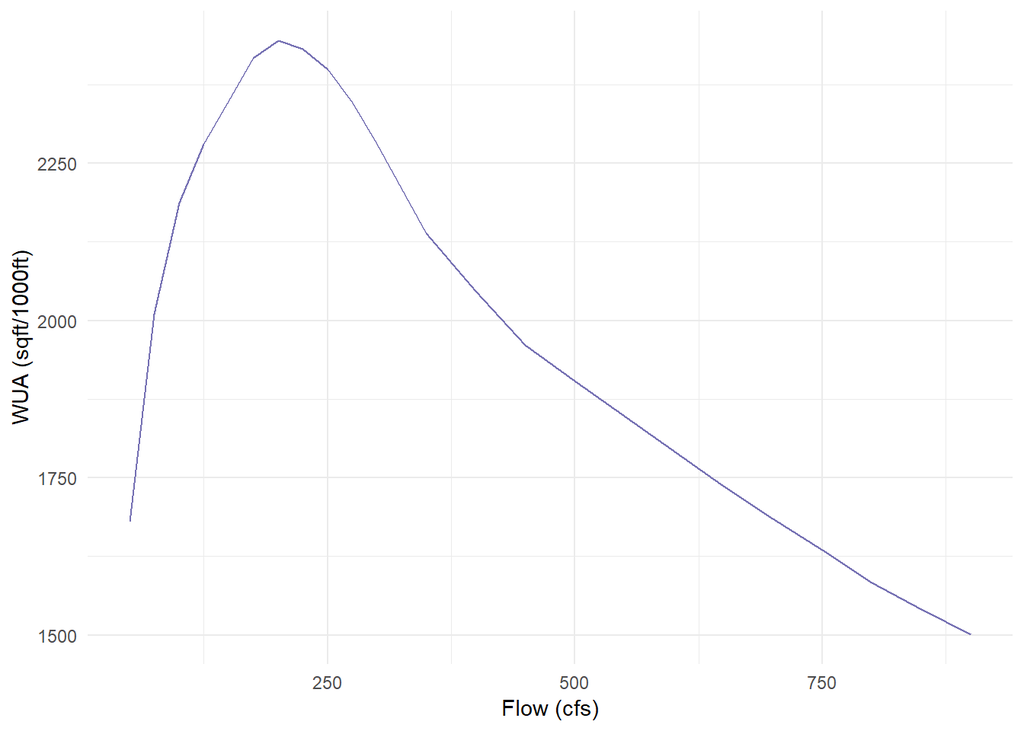

### Rearing WUA

The fry and juvenile instream rearing habitat weighted usable areas for Fall Run Chinook Salmon in Big Chico Creek.

#### Rearing WUA Plot

The following plot shows the weighted usable rearing area in square feet per thousand feet of river for Fall Run Chinook Salmon fry and juvenile. These rates are multiplied by the total rearing reach length mapped by the SIT.

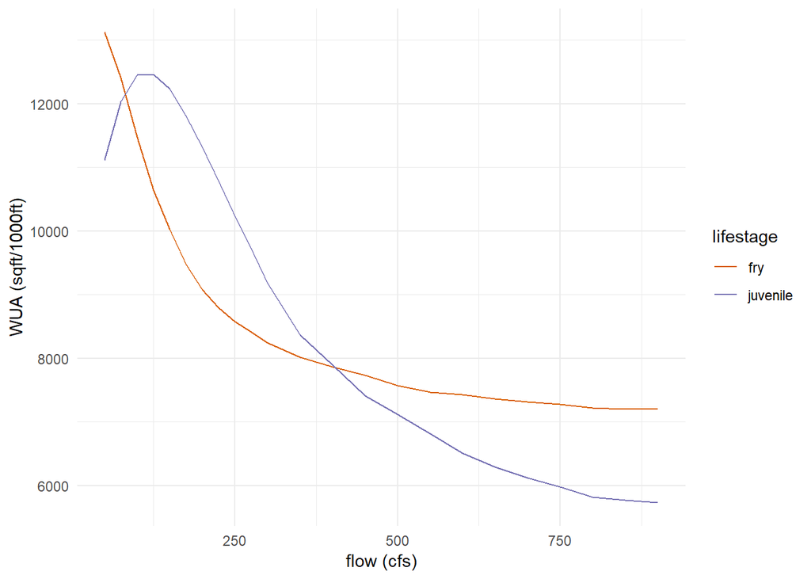

## Floodplain Modeling Details

**Data Source:** [Central Valley Floodplain Evaluation and Delineation (CVFED) HEC-RAS hydraulic model](https://s3-us-west-2.amazonaws.com/cvpiahabitat-r-package/cvpia-sit-model-inputs/CombinedTM_IQAR_Final-FULL-REPORT_20140206.pdf)

### Fall Run

A 8.7 mile portion of the entire mapped rearing extent of 15.1 miles was modeled using Central Valley Floodplain Evaluation and Delineation (CVFED) HEC-RAS hydraulic model. Of the entire mapped rearing extent, 15.1 miles were classified as low gradient and 0 miles were classified as high gradient based on a geomorphic analysis. Floodplain area per unit length was determined for the modeled extent and applied to determine areas for the non-modeled extent. A scaling factor of 0.1 was applied to the area per unit length for the high gradient extent. No scaling factor was applied to the low gradient extent.

### Spring Run and Steelhead

A 8.7 mile portion of the entire mapped rearing extent of 23.8 miles was modeled using Central Valley Floodplain Evaluation and Delineation (CVFED) HEC-RAS hydraulic model. Of the entire mapped rearing extent, 15.1 miles were classified as low gradient and 8.8 miles were classified as high gradient based on a geomorphic analysis. Floodplain area per unit length was determined for the modeled extent and applied to determine areas for the non-modeled extent. A scaling factor of 0.1 was applied to the area per unit length for the high gradient extent. No scaling factor was applied to the low gradient extent.

## Floodplain Data

| flow_cfs | FR_floodplain_acres | SR_floodplain_acres | ST_floodplain_acres | watershed |
| --- | --- | --- | --- | --- |
| 1215 | 0.000000 | 0.000000 | 0.000000 | Big Chico Creek |
| 1265 | 1.605321 | 1.699004 | 1.699004 | Big Chico Creek |
| 1315 | 4.209542 | 4.455202 | 4.455202 | Big Chico Creek |
| 1365 | 6.788936 | 7.185124 | 7.185124 | Big Chico Creek |
| 1415 | 10.011005 | 10.595226 | 10.595226 | Big Chico Creek |
| 1465 | 13.039604 | 13.800567 | 13.800567 | Big Chico Creek |
| 1515 | 15.689879 | 16.605507 | 16.605507 | Big Chico Creek |

## Floodplain Plot

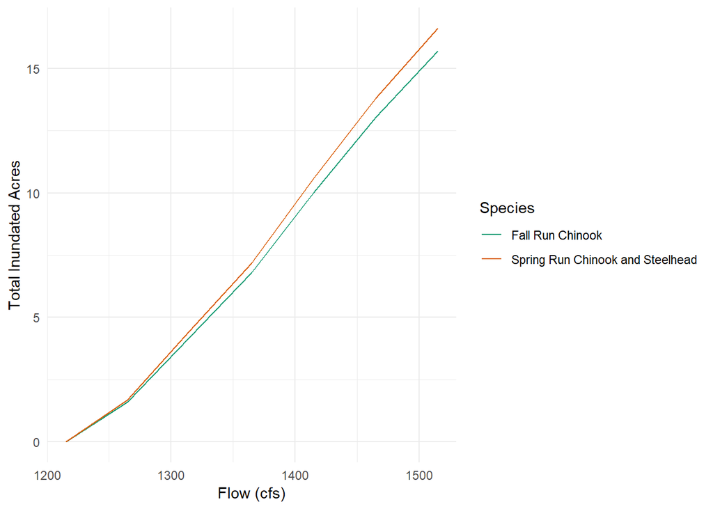